# Delineamento inteiramente casualizado

Eric Gorgens

1/17/2021

Este é sem dúvida o caso mais simples dos delineamentos experimentais. Aqui, o fenômeno de estudo se resume a apenas duas fontes de variação: uma fonte de variação conhecida determinada pelo tratamento e uma fonte de variação desconhecida determinada pelo resíduo.

## Recapitulando

A análise começa pela determinação das somas de quadrados total, composta pela soma de quadrados do tratamento e pela soma de quadrados do resíduo. Uma vez obtidas as somas de quadrados, calculam-se os quadrados médios e o valor da estatística F. Se F calculado for superior ao F tabelado, assume-se que existe um efeito devido aos tratamentos, ao passo que se F calculado for inferior ao F tabelado, não há evidências suficientes para rejeitar a hipótese nula, aceitando-se a hipótese de que não existe efeito dos tratamentos.

Sendo o efeito dos tratamentos significativo, realiza-se o desdobramento do efeito dos tratamentos através de um teste de médias se os tratamentos forem qualitativos, ou uma análise de regressão se os tratamentos forem quantitativos.

## O caso balanceado

Para exemplificar o caso balanceado, será analisado um estudo sobre a influência de três diferentes tipos de substrato no crescimento em altura de mudas. Cada tipo de substrato foi utilizado na germinação de 10 plantas. 90 dias após o semeio, as alturas das plântulas foram medidas e registradas numa planilha eletrônica (extensão .csv). Os dados podem ser resumidos através dos seguintes tópicos:

- Tratamento: 3 substratos
- 10 repetições
- Variável de interesse: altura

Abaixo seguem as medições de altura tabuladas. Embora o R seja compatível com diversas extensões de planilhas eletrônicas, utilizaremos ao longo do livro arquivos em extensão .csv.

Dados de delineamento inteiramente casualizado

| tratamento | rep | altura |
| --- | --- | --- |
| Substrato 1 | 1 | 1.2 |
| Substrato 1 | 2 | 8.6 |
| Substrato 1 | 3 | 8.6 |
| Substrato 1 | 4 | 3.7 |
| Substrato 1 | 5 | 9.9 |
| Substrato 1 | 6 | 2.5 |
| Substrato 1 | 7 | 6.2 |
| Substrato 1 | 8 | 6.2 |
| Substrato 1 | 9 | 1.2 |
| Substrato 1 | 10 | 3.7 |
| Substrato 2 | 1 | 2.5 |
| Substrato 2 | 2 | 8.6 |
| Substrato 2 | 3 | 7.4 |
| Substrato 2 | 4 | 6.2 |
| Substrato 2 | 5 | 9.9 |
| Substrato 2 | 6 | 2.5 |
| Substrato 2 | 7 | 6.2 |
| Substrato 2 | 8 | 6.2 |
| Substrato 2 | 9 | 1.2 |
| Substrato 2 | 10 | 3.7 |
| Substrato 3 | 1 | 3.7 |
| Substrato 3 | 2 | 9.9 |
| Substrato 3 | 3 | 11.1 |
| Substrato 3 | 4 | 7.4 |
| Substrato 3 | 5 | 7.4 |
| Substrato 3 | 6 | 3.7 |
| Substrato 3 | 7 | 6.2 |
| Substrato 3 | 8 | 8.6 |
| Substrato 3 | 9 | 11.1 |
| Substrato 3 | 10 | 11.1 |

O primeiro passo é importar o arquivo csv contendo os resultados do experimento para dentro do R. Esta tarefa pode ser realizada através do seguinte comando:

```r
dic1 = read.csv("./data/Experimento DIC 1.csv")
```

Lembre-se que de acordo com a formatação regional do seu computador pode ser necessário informar o separador de coluna e/ou separador decimal. Veja alguns exemplos de sintaxe logo em sequência.

```r
# Para o caso de separador decimal '.' e deparador de coluna','
dic1 = read.csv("Experimento DIC 1.csv", sep = ",", dec = ".")

# Para o caso de separador decimal ',' e separador de colune ';'
dic1 = read.csv("Experimento DIC 1.csv", sep = ";", dec = ",")
```

Com a importação, cria-se um objeto chamado dic1, contendo os dados do experimento num formato de dataframe. Antes de partir para a análise, é fundamental explorar os dados de forma gráfica para conhecer melhor os dados e antecipar o resultado da análise estatística. A construção do gráfico ajuda na compreensão do fenômeno estudado e na validação da análise estatística escolhida. Por se tratar de um experimento com o tratamento formado por níveis qualitativos, recomenda-se o uso do boxplot().

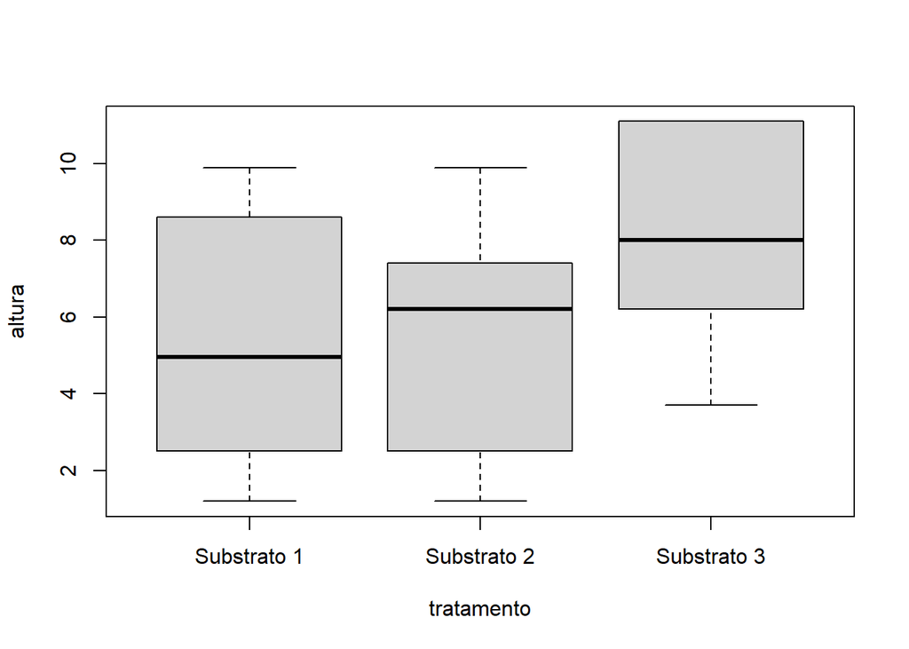

```r
boxplot(data = dic1, altura ~ tratamento)
```

Pelo gráfico obtido, é razoável esperar que não haja diferenças significativas entre os tratamentos (3 substratos), pois existe uma grande sobreposição entre os interquartis dos substratos. Assim, espera-se que a análise estatística do experimento corrobore a conclusão empírica baseada no interpretação do gráfico.

Com a função dic() do pacote ExpDes.pt será possível realizar toda a análise de um experimento de delineamento inteiramente casualizado, inclusive o desdobramento caso o teste F seja significativo e o tratamento tenha três ou mais níveis.

Lembre-se que O pacote ExpDes.pt não faz parte da instalação padrão do R, e precisa ser adicionado à parte. A sintaxe básica da função dic() é:

```r
dic(trat, resp, quali = TRUE, mcomp = "tukey", sigT = 0.05, sigF = 0.05)
```

No nosso experimento, não será necessário alterar nenhum parâmetro opcional, sendo então nosso comando construído da seguinte maneira:

```r
require(ExpDes.pt)
dic(dic1$tratamento, dic1$altura)
```

```
## ------------------------------------------------------------------------
## Quadro da analise de variancia
## ------------------------------------------------------------------------
##            GL      SQ QM     Fc    Pr>Fc
## Tratamento  2  49.299  2 2.7908 0.079121
## Residuo    27 238.476  3
## Total      29 287.775  1
## ------------------------------------------------------------------------
## CV = 47.83 %
##
## ------------------------------------------------------------------------
## Teste de normalidade dos residuos
## Valor-p:  0.06889791
## De acordo com o teste de Shapiro-Wilk a 5% de significancia, os residuos podem ser considerados normais.
## ------------------------------------------------------------------------
##
## ------------------------------------------------------------------------
## Teste de homogeneidade de variancia
## valor-p:  0.937449
## De acordo com o teste de bartlett a 5% de significancia, as variancias podem ser consideradas homogeneas.
## ------------------------------------------------------------------------
##
## De acordo com o teste F, as medias nao podem ser consideradas diferentes.
## ------------------------------------------------------------------------
##        Niveis Medias
## 1 Substrato 1   5.18
## 2 Substrato 2   5.44
## 3 Substrato 3   8.02
## ------------------------------------------------------------------------
```

O p-valor do *experimento’* foi 0.079121, o que equivale à um grau de significância de 7.9%. Sendo o nível de significância do nosso experimento é de 5%, o p-valor ficou acima da tolerância, indicando assim que o experimento não é significativo para um nível de 5%. Obviamente, também não é significativo para um nível de 1%.

Logo abaixo do quadro da ANOVA, é apresentado o coeficiente de variação do experimento (CV): 47.83%. O CV é utilizado para medir a precisão do experimento, representado pelo o desvio-padrão expresso como porcentagem da média. A interpretação do CV é muito subjetiva e varia muito entre as áreas da ciência. Na área das ciências agrárias, convencionou-se que valores acima de 30% são considerados excessivos.

Outra informação importante antes de aceitar o resultado da ANOVA, é verificar se os resíduos apresentam normalidade. Esta é uma pressuposição importante, uma vez que valida a escolha do modelo teórico do DIC para explicar o fenômeno:

$$Y = Xmed + TRAT + Erro$$

A não normalidade coloca em xeque o modelo teórico escolhido. Sendo então indicado a transformação dos dados e novo processamento da análise. A pressuposição deve então ser novamente verificada. Obtendo normalidade, os resultados obtidos com a variável transformada podem ser utilizados. Caso contrário, recomenda-se o uso de testes não paramétricos.

No nosso exemplo, o teste de normalidade foi não significativo (p-valor = 0.06) e portanto não há evidências para rejeitar a hipótese de normalidade dos resíduos.

A última parte da saída apresenta o resultado do desdobramento caso o teste F seja significativo. No nosso experimento, os tratamentos não são significativos e portanto, apresenta-se apenas a média de cada tratamento.

## Outro caso balanceado

Neste exemplo, segue um experimento em delineamento inteiramente casualizado, em que se avalia a resposta no desenvolvimento em altura das plantas de quatro níveis de um nutriente. Cada nível de nutriente foi repetido 6 vezes. Assim o experimento pode ser resumido como:

- Tratamento: 4 dosagens de um nutriente
- 6 repetições
- Variável de interesse: altura

Dados de outro delineamento inteiramente casualizado

| tratamento | rep | altura |
| --- | --- | --- |
| 0 | 1 | 32.3 |
| 0 | 2 | 50.6 |
| 0 | 3 | 50.6 |
| 0 | 4 | 38.8 |
| 0 | 5 | 37.1 |
| 0 | 6 | 26.3 |
| 25 | 1 | 46.3 |
| 25 | 2 | 50.3 |
| 25 | 3 | 47.5 |
| 25 | 4 | 45.6 |
| 25 | 5 | 63.9 |
| 25 | 6 | 36.3 |
| 50 | 1 | 68.5 |
| 50 | 2 | 93.9 |
| 50 | 3 | 96.5 |
| 50 | 4 | 77.7 |
| 50 | 5 | 77.7 |
| 50 | 6 | 68.8 |
| 75 | 1 | 26.3 |
| 75 | 2 | 40.3 |
| 75 | 3 | 37.7 |
| 75 | 4 | 35.1 |
| 75 | 5 | 33.9 |
| 75 | 6 | 26.3 |

O primeiro passo é importar o arquivo csv contendo os resultados do experimento para dentro do R. Esta tarefa pode ser realizada através do seguinte comando:

```r
dic2 = read.csv("./data/Experimento DIC 2.csv")
```

Antes de chamar a análise estatística, recomenda-se explorar os dados graficamente. Por se tratar de um tratamento de níveis quantitativos, o gráfico de dispersão é mais adequado:

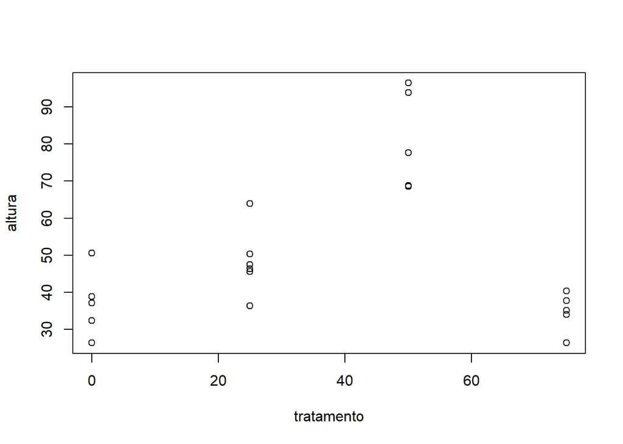

```r
plot(data = dic2, altura ~ tratamento)
```

O gráfico indica que a dosagem de 50 apresenta um desenvolvimento em altura superior às demais dosagens. Outro ponto que fica claro com o gráfico, é que o tratamento tem um efeito quadrático sobre a altura. Por se tratar de um caso balanceado, a análise estatística pode ser realizada com a função dic() do pacote ExpDes.pt:

```r
require(ExpDes.pt)
dic(dic2$tratamento, dic2$altura, quali = FALSE)
```

```
## ------------------------------------------------------------------------
## Quadro da analise de variancia
## ------------------------------------------------------------------------
##            GL     SQ QM     Fc     Pr>Fc
## Tratamento  3 7970.8  2 29.789 1.413e-07
## Residuo    20 1783.8  3
## Total      23 9754.7  1
## ------------------------------------------------------------------------
## CV = 18.76 %
##
## ------------------------------------------------------------------------
## Teste de normalidade dos residuos
## Valor-p:  0.1590112
## De acordo com o teste de Shapiro-Wilk a 5% de significancia, os residuos podem ser considerados normais.
## ------------------------------------------------------------------------
##
## ------------------------------------------------------------------------
## Teste de homogeneidade de variancia
## valor-p:  0.5117623
## De acordo com o teste de bartlett a 5% de significancia, as variancias podem ser consideradas homogeneas.
## ------------------------------------------------------------------------
##
## Ajuste de modelos polinomiais de regressao
## ------------------------------------------------------------------------
##
## Modelo Linear
## =========================================
##    Estimativa Erro.padrao   tc    valor.p
## -----------------------------------------
## b0  48.2233     3.2258    14.9493    0
## b1   0.0566     0.0690    0.8206  0.4215
## -----------------------------------------
##
## R2 do modelo linear
## --------
## 0.007536
## --------
##
## Analise de variancia do modelo linear
## ===========================================================
```

[output cut: 44 more lines]

```
## -
## 1
## -
##
## Analise de variancia do modelo cubico
## ===========================================================
##                      GL     SQ         QM      Fc   valor.p
## -----------------------------------------------------------
## Efeito linear        1   60.0668    60.0668   0.67  0.42152
## Efeito quadratico    1  4,751.7200 4,751.7200 53.28    0
## Efeito cubico        1  3,159.0540 3,159.0540 35.42  1e-05
## Desvios de Regressao 0      0          0        0      1
## Residuos             20 1,783.8380  89.1919
## -----------------------------------------------------------
## ------------------------------------------------------------------------
```

Note que o comando utilizado é muito semelhante ao exemplo anterior, com apenas uma diferença no parâmetro quali. Neste experimento, utiliza-se o parâmetro como FALSE por se tratar de um experimento com tratamento quantitativo.

O modelo estatístico pode ser aceito uma vez que não há evidências para rejeitar a hipótese de normalidade dos resíduos. Desta forma, pode-se dar sequência na interpretação dos resultados da análise do experimento.

Os tratamentos podem ser considerados significativos já que seu p-valor é inferior a 1%. O desdobramento do tratamento é realizado através de um teste de regressão, já que os níveis do tratamento são quantitativos.

A dose ótima do nutriente pode ser encontrado através do ponto de máximo do modelo quadrático considerando o intervalo dos níveis analisados, isto é, de 0 a 75. Cuidado com extrapolações, uma vez que o experimento não contempla doses fora do intervalo analisado.

## O caso desbalanceado

Experimentos desbalanceados são muito comuns na área das ciências agrárias. Isto ocorre principalmente devido à perda de parcelas ou unidades experimentais devido à contaminação, morte ou eventos não previstos. Voltaremos ao experimento em delineamento inteiramente casualizado, em que se avalia a resposta no desenvolvimento em altura das plantas de quatro níveis de um nutriente. Cada nível de nutriente foi repetido 6 vezes.

- Tratamento: 4 dosagens de um nutriente
- 6 repetições
- Variável de interesse: altura

No entanto, perceba que duas medições foram perdidas por morte das plantas:

- dose 0 repetição 4
- dose 75 repetição 2

Dados de outro delineamento inteiramente casualizado

| tratamento | rep | altura |
| --- | --- | --- |
| 0 | 1 | 32.3 |
| 0 | 2 | 50.6 |
| 0 | 3 | 50.6 |
| 0 | 5 | 37.1 |
| 0 | 6 | 26.3 |
| 25 | 1 | 46.3 |
| 25 | 2 | 50.3 |
| 25 | 3 | 47.5 |
| 25 | 4 | 45.6 |
| 25 | 5 | 63.9 |
| 25 | 6 | 36.3 |
| 50 | 1 | 68.5 |
| 50 | 2 | 93.9 |
| 50 | 3 | 96.5 |
| 50 | 4 | 77.7 |
| 50 | 5 | 77.7 |
| 50 | 6 | 68.8 |
| 75 | 1 | 26.3 |
| 75 | 3 | 37.7 |
| 75 | 4 | 35.1 |
| 75 | 5 | 33.9 |
| 75 | 6 | 26.3 |

O primeiro passo é importar o arquivo csv contendo os resultados do experimento para dentro do R. Esta tarefa pode ser realizada através do seguinte comando:

```r
dic3 = read.csv("./data/Experimento DIC 3.csv")
```

Antes de chamar a análise estatística, recomenda-se explorar os dados graficamente. Por se tratar de um tratamento de níveis quantitativos, o gráfico de dispersão é mais adequado:

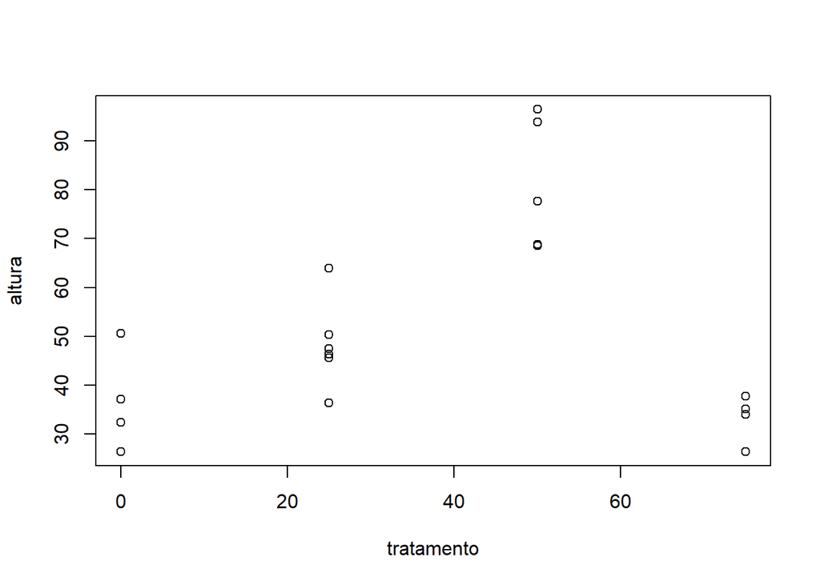

```r
plot(data = dic3, altura ~ tratamento)
```

Mesmo se tratando de um experimento desbalanceado, por se tratar de um DIC e consequentemente não existir interações a serem calculadas, pode-se utilizar a ANOVA Tipo I. Com relação aos parâmetros opcionais, apenas o parâmetro quali precisa ser alterado para FALSE, por se tratar tratamento quantitativo:

```r
require(ExpDes.pt)
dic(dic3$tratamento, dic3$altura, quali = FALSE)
```

```
## ------------------------------------------------------------------------
## Quadro da analise de variancia
## ------------------------------------------------------------------------
##            GL     SQ QM     Fc      Pr>Fc
## Tratamento  3 7775.1  2 27.056 6.8921e-07
## Residuo    18 1724.2  3
## Total      21 9499.3  1
## ------------------------------------------------------------------------
## CV = 19.07 %
##
## ------------------------------------------------------------------------
## Teste de normalidade dos residuos
## Valor-p:  0.1497467
## De acordo com o teste de Shapiro-Wilk a 5% de significancia, os residuos podem ser considerados normais.
## ------------------------------------------------------------------------
##
## ------------------------------------------------------------------------
## Teste de homogeneidade de variancia
## valor-p:  0.4610355
## De acordo com o teste de bartlett a 5% de significancia, as variancias podem ser consideradas homogeneas.
## ------------------------------------------------------------------------
##
## Ajuste de modelos polinomiais de regressao
## ------------------------------------------------------------------------
##
## Modelo Linear
## =========================================
##    Estimativa Erro.padrao   tc    valor.p
## -----------------------------------------
## b0  48.9626     3.5785    13.6823    0
## b1   0.0631     0.0775    0.8134  0.4266
## -----------------------------------------
##
## R2 do modelo linear
## --------
## 0.008151
## --------
##
## Analise de variancia do modelo linear
## ===========================================================
```

[output cut: 44 more lines]

```
## -
## 1
## -
##
## Analise de variancia do modelo cubico
## ===========================================================
##                      GL     SQ         QM      Fc   valor.p
## -----------------------------------------------------------
## Efeito linear        1   63.3741    63.3741   0.66  0.42662
## Efeito quadratico    1  4,523.1710 4,523.1710 47.22    0
## Efeito cubico        1  3,188.5220 3,188.5220 33.29  2e-05
## Desvios de Regressao 0      0          0        0      1
## Residuos             18 1,724.1970  95.7887
## -----------------------------------------------------------
## ------------------------------------------------------------------------
```

A interpretação é semelhantes aos experimentos apresentados anteriormente.